# Peer Graded Assignment: Prediction Assignment Writeup

Tadashi Horie

2016年6月28日

# Overview

The goal of this project is to predict the manner in which they did the exercise. This is the “classe” variable in the training set. This report describes how data was cleaned, how I split “pml-training.csv” into train set and test set, and some of models are investigated.

# Exercise

#### **1. Loading add-on package and set seed**

```r
set.seed(12345)
library(caret)
```

#### **2. Download rawdata and submit_data**

```r
url_train <- "https://d396qusza40orc.cloudfront.net/predmachlearn/pml-training.csv"
rawdata <- read.csv(url_train, na.strings = c("", "NA"))
url_submit <- "https://d396qusza40orc.cloudfront.net/predmachlearn/pml-testing.csv"
submit_data <- read.csv(url_submit, na.strings = c("", "NA"))
```

#### **3. Cleaning data**

We should delete the column that contains NA to avoid the error. In addition, in order to make accurate predictions, columns that is not related exercise must also be deleted. In particular “X”, “user_name”, “raw_timestamp_part_1”, “raw_timestamp_part_2”, “cvtd_timestamp”, “new_window”, “num_window” are deleted.

```r
#Remove NA cols
colname <- colnames(rawdata)[!colSums(is.na(rawdata)) > 0]
colname
```

```
##  [1] "X"                    "user_name"            "raw_timestamp_part_1"
##  [4] "raw_timestamp_part_2" "cvtd_timestamp"       "new_window"
##  [7] "num_window"           "roll_belt"            "pitch_belt"
## [10] "yaw_belt"             "total_accel_belt"     "gyros_belt_x"
## [13] "gyros_belt_y"         "gyros_belt_z"         "accel_belt_x"
## [16] "accel_belt_y"         "accel_belt_z"         "magnet_belt_x"
## [19] "magnet_belt_y"        "magnet_belt_z"        "roll_arm"
## [22] "pitch_arm"            "yaw_arm"              "total_accel_arm"
## [25] "gyros_arm_x"          "gyros_arm_y"          "gyros_arm_z"
## [28] "accel_arm_x"          "accel_arm_y"          "accel_arm_z"
## [31] "magnet_arm_x"         "magnet_arm_y"         "magnet_arm_z"
## [34] "roll_dumbbell"        "pitch_dumbbell"       "yaw_dumbbell"
## [37] "total_accel_dumbbell" "gyros_dumbbell_x"     "gyros_dumbbell_y"
## [40] "gyros_dumbbell_z"     "accel_dumbbell_x"     "accel_dumbbell_y"
## [43] "accel_dumbbell_z"     "magnet_dumbbell_x"    "magnet_dumbbell_y"
## [46] "magnet_dumbbell_z"    "roll_forearm"         "pitch_forearm"
## [49] "yaw_forearm"          "total_accel_forearm"  "gyros_forearm_x"
## [52] "gyros_forearm_y"      "gyros_forearm_z"      "accel_forearm_x"
## [55] "accel_forearm_y"      "accel_forearm_z"      "magnet_forearm_x"
## [58] "magnet_forearm_y"     "magnet_forearm_z"     "classe"
```

```r
#Slice data related with exercise
colname <- colname[8: length(colname)]
df_wo_NA <- rawdata[colname]

#Check the colnames of df_wo_NA is in submit_data.
#The last colname is "classe"
is.element(colname, colnames(submit_data))
```

```
##  [1]  TRUE  TRUE  TRUE  TRUE  TRUE  TRUE  TRUE  TRUE  TRUE  TRUE  TRUE
## [12]  TRUE  TRUE  TRUE  TRUE  TRUE  TRUE  TRUE  TRUE  TRUE  TRUE  TRUE
## [23]  TRUE  TRUE  TRUE  TRUE  TRUE  TRUE  TRUE  TRUE  TRUE  TRUE  TRUE
## [34]  TRUE  TRUE  TRUE  TRUE  TRUE  TRUE  TRUE  TRUE  TRUE  TRUE  TRUE
## [45]  TRUE  TRUE  TRUE  TRUE  TRUE  TRUE  TRUE  TRUE FALSE
```

#### **4. Split data into random train and test**

```r
inTrain = createDataPartition(df_wo_NA$classe, p = 3/4)[[1]]
training = df_wo_NA[ inTrain,]
testing = df_wo_NA[-inTrain,]
```

#### **4. Random Forest**

It takes a very long time for training, but it has a high accuracy.

```r
model_rf <- train(classe ~ ., data = training, method = "rf")
pred_rf <- predict(model_rf, testing)
confusionMatrix(testing$classe, pred_rf)
```

```
## Confusion Matrix and Statistics
##
##           Reference
## Prediction    A    B    C    D    E
##          A 1395    0    0    0    0
##          B    9  934    6    0    0
##          C    0    3  848    4    0
##          D    0    0    3  801    0
##          E    0    0    1    1  899
##
## Overall Statistics
##
##                Accuracy : 0.9945
##                  95% CI : (0.992, 0.9964)
##     No Information Rate : 0.2863
##     P-Value [Acc > NIR] : < 2.2e-16
##
##                   Kappa : 0.993
##  Mcnemar's Test P-Value : NA
##
## Statistics by Class:
##
##                      Class: A Class: B Class: C Class: D Class: E
## Sensitivity            0.9936   0.9968   0.9883   0.9938   1.0000
## Specificity            1.0000   0.9962   0.9983   0.9993   0.9995
## Pos Pred Value         1.0000   0.9842   0.9918   0.9963   0.9978
## Neg Pred Value         0.9974   0.9992   0.9975   0.9988   1.0000
## Prevalence             0.2863   0.1911   0.1750   0.1644   0.1833
## Detection Rate         0.2845   0.1905   0.1729   0.1633   0.1833
## Detection Prevalence   0.2845   0.1935   0.1743   0.1639   0.1837
## Balanced Accuracy      0.9968   0.9965   0.9933   0.9965   0.9998
```

#### **5. Liner Discriminant Analysis**

It takes a short time but poor accuracy.

```r
model_lda <- train(classe ~ ., data = training, method = "lda")
pred_lda <- predict(model_lda, testing)
confusionMatrix(testing$classe, pred_lda)
```

```
## Confusion Matrix and Statistics
##
##           Reference
## Prediction    A    B    C    D    E
##          A 1150   29  103  103   10
##          B  159  589  125   34   42
##          C  100   71  558  101   25
##          D   34   40   89  609   32
##          E   31  151   84   83  552
##
## Overall Statistics
##
##                Accuracy : 0.7051
##                  95% CI : (0.6922, 0.7179)
##     No Information Rate : 0.3006
##     P-Value [Acc > NIR] : < 2.2e-16
##
##                   Kappa : 0.6267
##  Mcnemar's Test P-Value : < 2.2e-16
##
## Statistics by Class:
##
##                      Class: A Class: B Class: C Class: D Class: E
## Sensitivity            0.7802   0.6693   0.5819   0.6548   0.8351
## Specificity            0.9286   0.9105   0.9247   0.9509   0.9177
## Pos Pred Value         0.8244   0.6207   0.6526   0.7575   0.6127
## Neg Pred Value         0.9077   0.9264   0.9010   0.9217   0.9728
## Prevalence             0.3006   0.1794   0.1956   0.1896   0.1348
## Detection Rate         0.2345   0.1201   0.1138   0.1242   0.1126
## Detection Prevalence   0.2845   0.1935   0.1743   0.1639   0.1837
## Balanced Accuracy      0.8544   0.7899   0.7533   0.8029   0.8764
```

#### **6. Recursive Partitioning and Regression Trees**

The results can be confirmed visually, but poor accuracy.

```r
model_rpart <- train(classe ~ ., data = training, method = "rpart")
pred_rpart<- predict(model_rpart, testing)
confusionMatrix(testing$classe, pred_rpart)
```

```
## Confusion Matrix and Statistics
##
##           Reference
## Prediction   A   B   C   D   E
##          A 859 215 203 109   9
##          B 151 434 166 197   1
##          C  27 117 442 269   0
##          D  43  65 131 492  73
##          E  14 143 111 133 500
##
## Overall Statistics
##
##                Accuracy : 0.5561
##                  95% CI : (0.542, 0.57)
##     No Information Rate : 0.2447
##     P-Value [Acc > NIR] : < 2.2e-16
##
##                   Kappa : 0.4442
##  Mcnemar's Test P-Value : < 2.2e-16
##
## Statistics by Class:
##
##                      Class: A Class: B Class: C Class: D Class: E
## Sensitivity            0.7852   0.4456  0.41975   0.4100   0.8576
## Specificity            0.8593   0.8690  0.89276   0.9158   0.9072
## Pos Pred Value         0.6158   0.4573  0.51696   0.6119   0.5549
## Neg Pred Value         0.9330   0.8635  0.84910   0.8273   0.9793
## Prevalence             0.2231   0.1986  0.21472   0.2447   0.1189
## Detection Rate         0.1752   0.0885  0.09013   0.1003   0.1020
## Detection Prevalence   0.2845   0.1935  0.17435   0.1639   0.1837
## Balanced Accuracy      0.8223   0.6573  0.65625   0.6629   0.8824
```

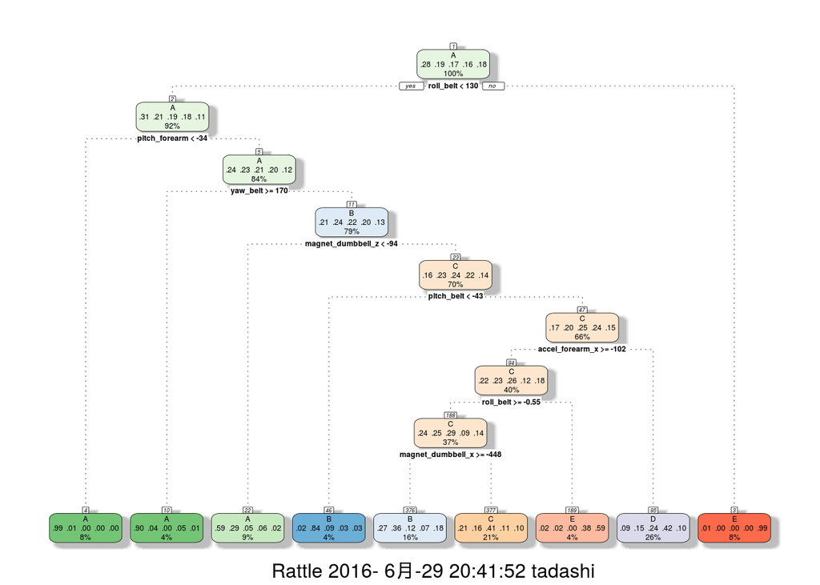

```r
library(rattle)
fancyRpartPlot(model_rpart$finalModel)
```

#### **7. Submit data with Random Forest**

We use the high accuracy model to submit data. In this report the Random Forest accuracy has the highest value 99.45. We can show head of the prediction.

```r
submit_rf <- predict(model_rf, submit_data)
submit_rf
```

```
##  [1] B A B A A E D B A A B C B A E E A B B B
## Levels: A B C D E
```